# Exercises 5: Data visualization, part 1: Base R

Author

Affiliation

Guillem Ylla, PhD

Jagiellonian University

```r
knitr::opts_chunk$set(echo = TRUE)
library(rmarkdown)
```

## Data

For the following examples, we will be working on 2 datasets: **iris** and **Table_TPMs**.

### Load iris dataset

R contains datasets to work as example data. Here we load a data set called “iris”, with measurements on 3 iris species.

```r
data("iris")

paged_table(iris)
```

| Sepal.Length | Sepal.Width | Petal.Length | Petal.Width | Species |
| --- | --- | --- | --- | --- |
| 5.1 | 3.5 | 1.4 | 0.2 | setosa |
| 4.9 | 3.0 | 1.4 | 0.2 | setosa |
| 4.7 | 3.2 | 1.3 | 0.2 | setosa |
| 4.6 | 3.1 | 1.5 | 0.2 | setosa |
| 5.0 | 3.6 | 1.4 | 0.2 | setosa |
| 5.4 | 3.9 | 1.7 | 0.4 | setosa |
| 4.6 | 3.4 | 1.4 | 0.3 | setosa |
| 5.0 | 3.4 | 1.5 | 0.2 | setosa |
| 4.4 | 2.9 | 1.4 | 0.2 | setosa |
| 4.9 | 3.1 | 1.5 | 0.1 | setosa |

[output cut: 140 more lines]

[figure not shown]

### Read expression data from csv

We load the TPM table resulting from a mRNA-seq analysis on *D. melanogaster* in 3 control samples and 3 treated samples. To reduce computing time, the file only contains 100 genes (out of ~15,000).

```r
Table_TPMs<-read.csv("data/TPMs_table_100genes.csv",row.names=1)
class(Table_TPMs)
```

```
[1] "data.frame"
```

```r
paged_table(Table_TPMs)
```

|  | Control_1 | Control_2 | Control_3 | Treated_1 | Treated_2 | Treated_3 |
| --- | --- | --- | --- | --- | --- | --- |
| FBgn0000003 | 373.9151121 | 207.56604753 | 161.44662478 | 72.2354952 | 114.99103054 | 54.43069566 |
| FBgn0000008 | 11.9230172 | 10.49210216 | 14.24191558 | 8.5286560 | 10.69058505 | 4.63866309 |
| FBgn0000014 | 6.4022874 | 69.44733911 | 126.54632777 | 109.3568512 | 92.69300335 | 179.47255396 |
| FBgn0000015 | 14.8528238 | 9.17268809 | 11.50461054 | 2.1043061 | 1.48446818 | 5.21519958 |
| FBgn0000017 | 25.2391875 | 24.41756794 | 27.40004110 | 33.3331524 | 36.85823416 | 21.36512798 |
| FBgn0000018 | 46.0794095 | 35.69151424 | 28.90138453 | 49.7805807 | 58.25302601 | 36.80263173 |
| FBgn0000022 | 2.8054033 | 2.29044553 | 1.11452803 | 0.2399126 | 1.11269389 | 0.00000000 |
| FBgn0000024 | 0.0000000 | 0.32351707 | 0.71054004 | 1.3011833 | 1.10447769 | 2.69754821 |
| FBgn0000028 | 0.9052952 | 2.74650490 | 1.60122933 | 1.4224874 | 1.72546680 | 0.52047480 |
| FBgn0000032 | 20.1216780 | 45.05265890 | 26.41958079 | 57.6106395 | 43.52203032 | 48.82952549 |

[output cut: 90 more lines]

## Scatter plots

For this section we will use **iris** dataset.

The base R function `plot()` expects to get y and x values.

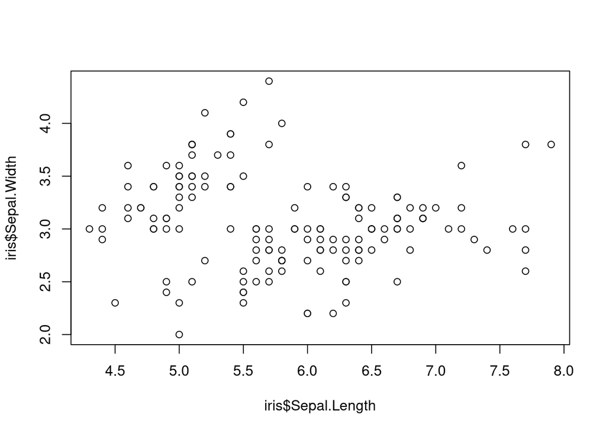

```r
plot(iris$Sepal.Length, iris$Sepal.Width)
```

Same way, we can now plot Petal length vs width.

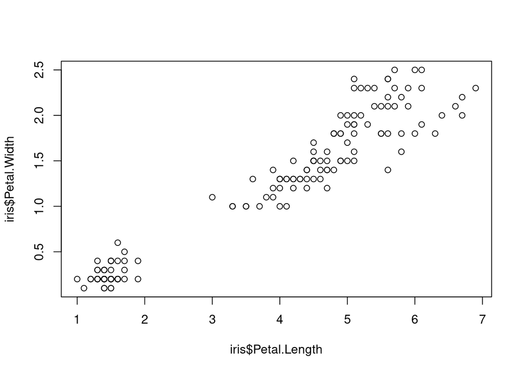

```r
plot(iris$Petal.Length, iris$Petal.Width)
```

### Exercise 1

- Plot Sepal Length vs Petal Length.

```r
## YOUR CODE HERE
```

### Exercise 2

- Plot species vs Petal Length.

```r
## YOUR CODE HERE
```

- What happens now?

The `plot` function will try to adjust the plot to the data. If x variable is categorical (e.g. Species) and the other y continuous (e.g. Sepal.Length) will make a boxplot.

## Boxplots

Here, we will use the **TPMs data from gene expression**.

Let’s make a boxlot in base R. Showing for each sample, the expression of all genes in it.

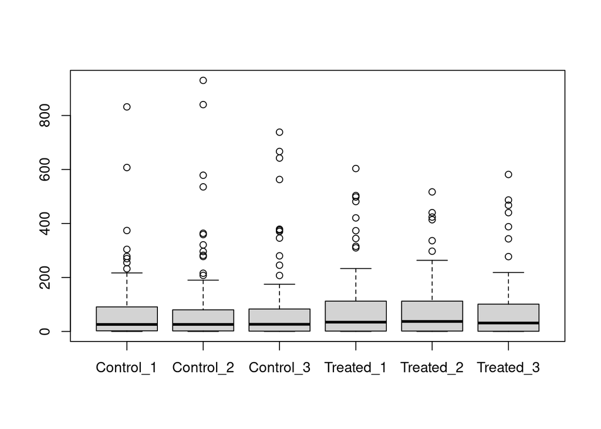

```r
boxplot(Table_TPMs)
```

Let’s put labels on the axes, and title:

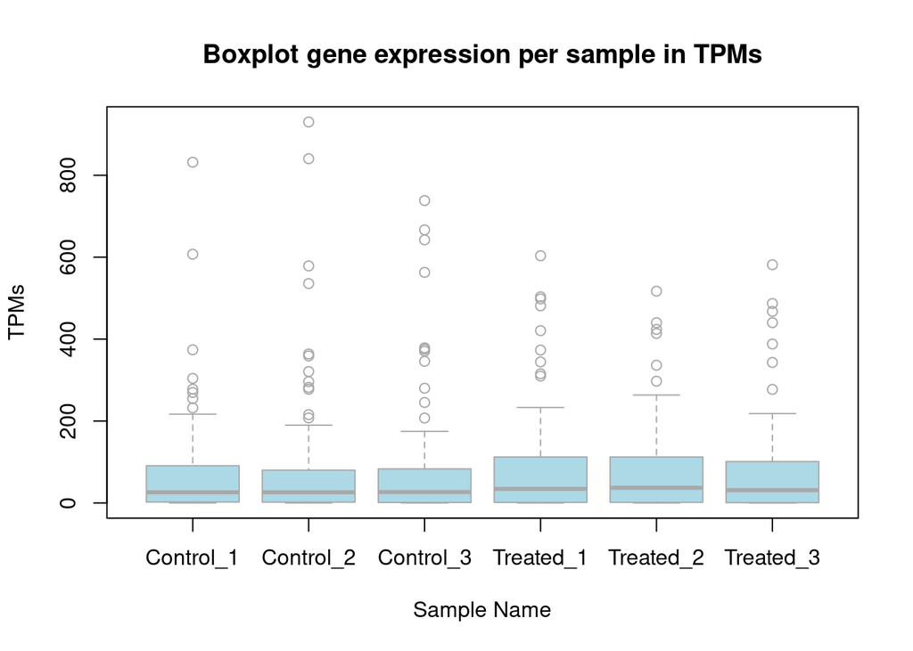

```r
boxplot(Table_TPMs, col="lightblue", border="darkgrey",  ylab="TPMs", xlab="Sample Name", main="Boxplot gene expression per sample in TPMs")
```

Remove outliers.

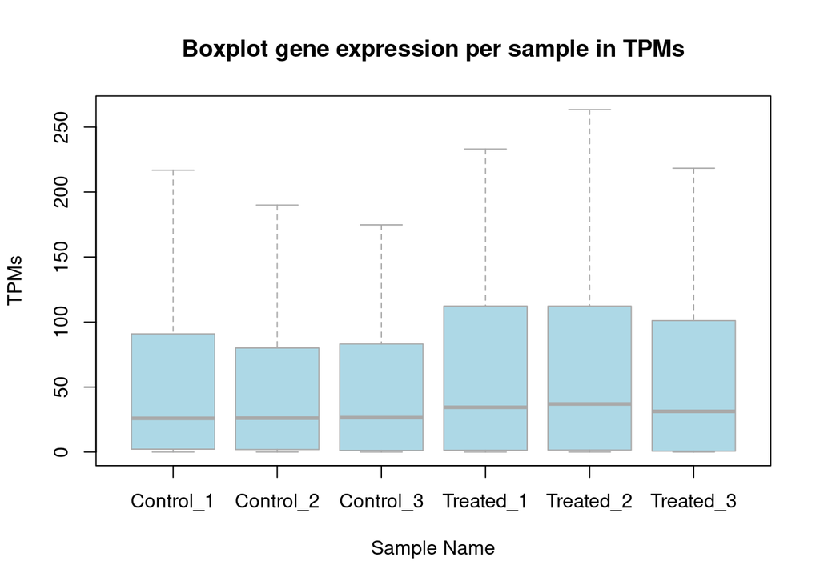

```r
boxplot(Table_TPMs, col="lightblue", border="darkgrey", outline=FALSE, ylab="TPMs", xlab="Sample Name", main="Boxplot gene expression per sample in TPMs")
```

### Exercise 3

- Make a Boxplot of the **iris** dataset to show for each **species** the **Sepal Width** using boxplot function().
- Color the boxes in a color encoded by Hex code “#a4eb34”.
- Add title and labels.

```r
## YOUR CODE HERE
```